# R Notebook

```r
library(ggplot2)
summary(diamonds)
```

```
     carat               cut        color
 Min.   :0.2000   Fair     : 1610   D: 6775
 1st Qu.:0.4000   Good     : 4906   E: 9797
 Median :0.7000   Very Good:12082   F: 9542
 Mean   :0.7979   Premium  :13791   G:11292
 3rd Qu.:1.0400   Ideal    :21551   H: 8304
 Max.   :5.0100                     I: 5422
                                    J: 2808
    clarity          depth           table
 SI1    :13065   Min.   :43.00   Min.   :43.00
 VS2    :12258   1st Qu.:61.00   1st Qu.:56.00
 SI2    : 9194   Median :61.80   Median :57.00
 VS1    : 8171   Mean   :61.75   Mean   :57.46
 VVS2   : 5066   3rd Qu.:62.50   3rd Qu.:59.00
 VVS1   : 3655   Max.   :79.00   Max.   :95.00
 (Other): 2531
     price             x                y
 Min.   :  326   Min.   : 0.000   Min.   : 0.000
 1st Qu.:  950   1st Qu.: 4.710   1st Qu.: 4.720
 Median : 2401   Median : 5.700   Median : 5.710
 Mean   : 3933   Mean   : 5.731   Mean   : 5.735
 3rd Qu.: 5324   3rd Qu.: 6.540   3rd Qu.: 6.540
 Max.   :18823   Max.   :10.740   Max.   :58.900

       z              volume
 Min.   : 0.000   Min.   :   0.00
 1st Qu.: 2.910   1st Qu.:  65.14
 Median : 3.530   Median : 114.81
 Mean   : 3.539   Mean   : 129.85
 3rd Qu.: 4.040   3rd Qu.: 170.84
 Max.   :31.800   Max.   :3840.60
```

#### 钻石价格直方图

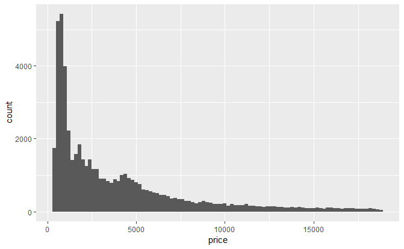

```r
ggplot(aes(x = price), data = diamonds) +
  geom_histogram(binwidth = 200)
```

```r
diamonds[diamonds$price >= 15000,]
```

| carat | cut | color | clarity | depth | table | price | x | y | z | volume |
| --- | --- | --- | --- | --- | --- | --- | --- | --- | --- | --- |
| 1.60 | Ideal | G | VS2 | 61.9 | 56.0 | 15000 | 7.53 | 7.47 | 4.64 | 260.9958 |
| 1.54 | Premium | E | VS2 | 62.3 | 58.0 | 15002 | 7.31 | 7.39 | 4.58 | 247.4157 |
| 1.19 | Ideal | F | VVS1 | 61.5 | 55.0 | 15005 | 6.82 | 6.84 | 4.20 | 195.9250 |
| 2.10 | Premium | I | SI1 | 61.5 | 57.0 | 15007 | 8.25 | 8.21 | 5.06 | 342.7264 |
| 1.69 | Ideal | D | SI1 | 60.8 | 57.0 | 15011 | 7.69 | 7.71 | 4.68 | 277.4767 |
| 1.50 | Very Good | G | VVS2 | 62.9 | 56.0 | 15013 | 7.22 | 7.32 | 4.57 | 241.5263 |
| 1.73 | Very Good | G | VS1 | 62.8 | 57.0 | 15014 | 7.57 | 7.72 | 4.80 | 280.5139 |
| 2.02 | Premium | G | SI2 | 63.0 | 59.0 | 15014 | 8.05 | 7.95 | 5.03 | 321.9074 |
| 2.05 | Very Good | F | SI2 | 61.9 | 56.0 | 15017 | 8.13 | 8.18 | 5.05 | 335.8422 |
| 1.50 | Very Good | F | VS1 | 61.6 | 58.0 | 15022 | 7.35 | 7.43 | 4.55 | 248.4778 |

[output cut: 990 more lines]

Explore the largest peak in the price histogram you created earlier. Try limiting the x-axis, altering the bin width, and setting different breaks on the x-axis.

You can save images by using the ggsave() command. ggsave() will save the last plot created. For example… qplot(x = price, data = diamonds) ggsave(‘priceHistogram.png’)

ggsave currently recognises the extensions eps/ps, tex (pictex), pdf, jpeg, tiff, png, bmp, svg and wmf (windows only).

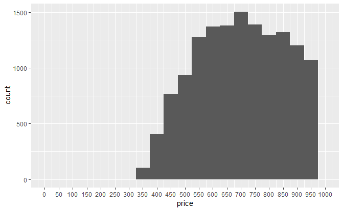

```r
ggplot(aes(x = price), data = diamonds) +
  geom_histogram(binwidth = 50) +
  scale_x_continuous(limits = c(0, 1000), breaks = seq(0, 1000, 50))
ggsave('priceHistogram.png')
```

#### 切工-价格直方图

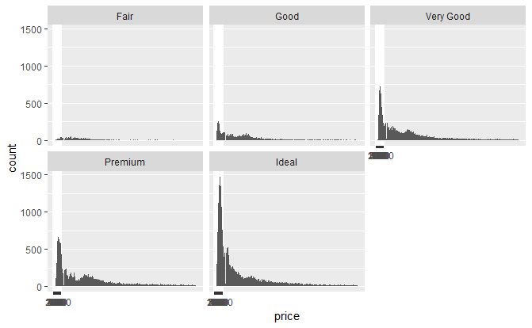

```r
ggplot(aes(x = price), data = diamonds) +
  geom_histogram(binwidth = 100) +
  scale_x_continuous(breaks = seq(0, 1000, 100)) +
  facet_wrap(~cut)
```

```r
table(diamonds$cut)
```

```
     Fair      Good Very Good   Premium     Ideal
     1610      4906     12082     13791     21551
```

```r
by(diamonds$price, diamonds$cut, summary)
```

```
diamonds$cut: Fair
   Min. 1st Qu.  Median    Mean 3rd Qu.    Max.
    337    2050    3282    4359    5206   18574
--------------------------------------------
diamonds$cut: Good
   Min. 1st Qu.  Median    Mean 3rd Qu.    Max.
    327    1145    3050    3929    5028   18788
--------------------------------------------
diamonds$cut: Very Good
   Min. 1st Qu.  Median    Mean 3rd Qu.    Max.
    336     912    2648    3982    5373   18818
--------------------------------------------
diamonds$cut: Premium
   Min. 1st Qu.  Median    Mean 3rd Qu.    Max.
    326    1046    3185    4584    6296   18823
--------------------------------------------
diamonds$cut: Ideal
   Min. 1st Qu.  Median    Mean 3rd Qu.    Max.
    326     878    1810    3458    4678   18806
```

#### 标尺和多直方图

http://www.cookbook-r.com/Graphs/Facets_(ggplot2)/

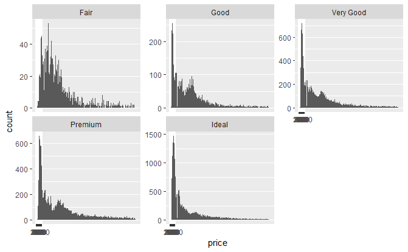

```r
ggplot(aes(x = price), data = diamonds) +
  geom_histogram(binwidth = 100) +
  scale_x_continuous(breaks = seq(0, 1000, 100)) +
  facet_wrap(~cut, scales="free_y")
```

提示 1：你可以在参数 x 中使用价格和克拉变量。什么表达式可使你得到每克拉价格？ 提示 2：对于长尾分布，你可以添加一个 ggplot 图层（如：scale_x_log10()）来转换变量。

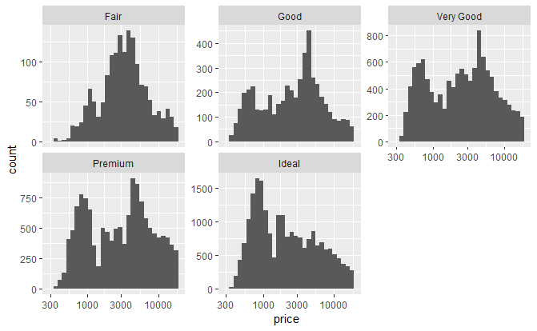

```r
library(gridExtra)
ggplot(aes(x = price), data = diamonds) +
  geom_histogram() +
  facet_wrap(~cut, scales="free_y") +
  scale_x_log10()
```

```r
NA
```

#### 价格箱线图

在箱线图中，我们将 y 参数作为连续数据，将 x 参数作为分类数据。

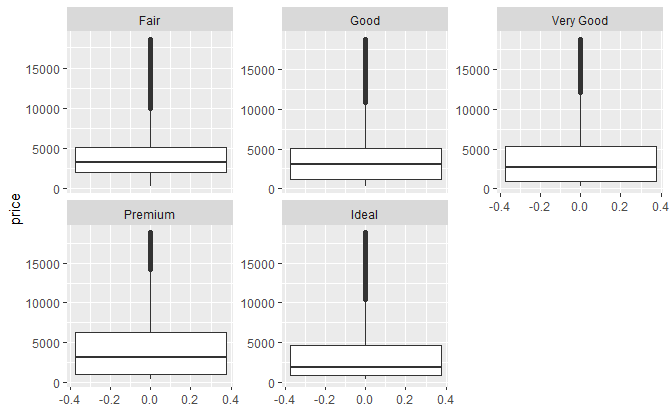

```r
ggplot(aes(y = price), data = diamonds) +
  geom_boxplot() +
  facet_wrap(~cut, scales="free_y") +
  coord_cartesian()
```

#### 四分位数间距 — IQR

```r
IQR(subset(diamonds, price <1000)$price)
```

```
[1] 261
```

```r
IQR(subset(diamonds, color =='D')$price)
```

```
[1] 3302.5
```

```r
IQR(subset(diamonds, color =='J')$price)
```

```
[1] 5834.5
```

```r
by(diamonds$price, diamonds$color, summary)
```

```
diamonds$color: D
   Min. 1st Qu.  Median    Mean 3rd Qu.    Max.
    357     911    1838    3170    4214   18693
--------------------------------------------
diamonds$color: E
   Min. 1st Qu.  Median    Mean 3rd Qu.    Max.
    326     882    1739    3077    4003   18731
--------------------------------------------
diamonds$color: F
   Min. 1st Qu.  Median    Mean 3rd Qu.    Max.
    342     982    2344    3725    4868   18791
--------------------------------------------
diamonds$color: G
   Min. 1st Qu.  Median    Mean 3rd Qu.    Max.
    354     931    2242    3999    6048   18818
--------------------------------------------
diamonds$color: H
   Min. 1st Qu.  Median    Mean 3rd Qu.    Max.
    337     984    3460    4487    5980   18803
--------------------------------------------
diamonds$color: I
   Min. 1st Qu.  Median    Mean 3rd Qu.    Max.
    334    1120    3730    5092    7202   18823
--------------------------------------------
diamonds$color: J
   Min. 1st Qu.  Median    Mean 3rd Qu.    Max.
    335    1860    4234    5324    7695   18710
```

#### 由颜色表示的每克拉价格箱线图

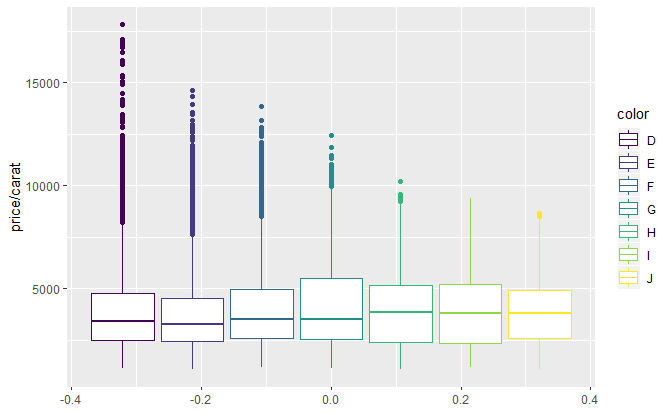

```r
ggplot(aes(y = price/carat), data = diamonds) +
  geom_boxplot(aes(color = color))
```

#### 克拉频率多边形

对于这个问题，我们寻找的是精确值的计数 — 尝试从较大的组宽开始，接着减小组宽，以查看图形是如何变化的，然后关注你最感兴趣的值。

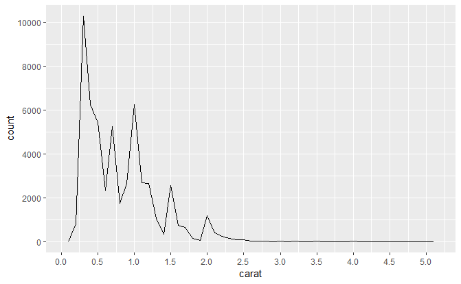

```r
ggplot(aes(x = carat), data = diamonds) +
  geom_freqpoly(binwidth=0.1) +
  scale_x_continuous(breaks = seq(0, 5, 0.5)) +
  scale_y_continuous(breaks = seq(0,10000,2000))
```

```r
NA
```

#### Gapminder 数据

The Gapminder website contains over 500 data sets with information about the world’s population. Your task is to download a data set of your choice and create 2-5 plots that make use of the techniques from Lesson 3.

You might use a simple histogram, a boxplot split over a categorical variable, or a frequency polygon. The choice is yours!

You can find a link to the Gapminder website in the Instructor Notes.

Once you’ve completed your investigation, create a post in the discussions that includes: 1. any questions you answered, your observations, and summary statistics 2. snippets of code that created the plots 3. links to the images of your plots